# Data Analysis

# Description of Goals

We aim to use the maldifish appraoch to determine if mass spectral data classify according to symbiont/host tissue locations using both a spatial clustering framework and the discriminate analysis appraoch. Maldi data was peak-picked using PeakPicking.R script and processed to reduce dimensions (Data_Processing.R). Additionally, cluster analysis was preformed on the high-memory node in Cologne and resulting cluster data is in associated R Files. This script depends on the following RData Files : *Cardinal_Processed_Data.RData*, *supervised-clustering-anlaysis.RData*, *unspervised-clustering-anlaysis.RData*

Set up working space

```r
rm(list=ls())
library(Cardinal)
library(VennDiagram)
library(ggplot2)
dir<-"/home/maggie/Documents/Projects/maldifish/RAnalysis"
setwd(file.path(dir,'Data'))
load('Cardinal_Processed_Data.RData')
maldifishmz
```

```
An object of class "MSImageSet"
Slot "processingData":
Processing data
  Cardinal version: 1.7.0
  Files: /opt/extern/bremen/symbiosis/sogin/MALDIFISH/Data/20161206_MPIBremen_Bputeoserpentis_MALDI-FISH8_Sl16_s1_DHB_233x233_3um.imzML
         /opt/extern/bremen/symbiosis/sogin/MALDIFISH/Data/20161206_MPIBremen_Bputeoserpentis_MALDI-FISH8_Sl16_s1_DHB_233x233_3um.ibd
  Normalization: tic
  Smoothing:
  Baseline reduction:
  Spectrum representation:
  Peak picking: adaptive

Slot "experimentData":
Experiment data
  Experimenter name:
  Laboratory:
  Contact:
  Title:
  URL:
  PMIDs:
  No abstract available.

Slot "imageData":
An object of class 'MSImageData'
  iData: 3495 x 21386 matrix (570.3 Mb)
  mzData: 3495 x 21386 Hashmat (254.1 Mb)
  peakData: 3495 x 21386 Hashmat (254.1 Mb)

Slot "pixelData":
An object of class 'IAnnotatedDataFrame'
  pixelNames: x = 1, y = 1 x = 2, y = 1 ... x = 230, y = 233 (21386 total)
  varLabels: x y sample Class
  varMetadata: labelType labelDescription

Slot "featureData":
An object of class 'AnnotatedDataFrame'
  featureNames: m/z = 405.059 m/z = 408.009 ... m/z = 1199.171 (3495 total)
  varLabels: mz
  varMetadata: labelDescription

Slot "protocolData":
An object of class 'AnnotatedDataFrame': none

Slot ".__classVersion__":
         R    Biobase       iSet  SImageSet MSImageSet
   "3.2.4"   "2.30.0"    "0.1.0"    "0.1.0"    "0.7.0"
```

Add in a cross validation group for classification

```r
for (i in 1:25){
  print(table(df[which(df$cvgroup==i),'Class']))
}
```

```
 Green  Mixed    Red Tissue
    79     52    308   1719

 Green  Mixed    Red Tissue
    80     44    294   1724

 Green  Mixed    Red Tissue
    72     49    301   1691

 Green  Mixed    Red Tissue
    77     47    307   1624

 Green  Mixed    Red Tissue
    83     53    279   1702

 Green  Mixed    Red Tissue
    84     44    327   1680

 Green  Mixed    Red Tissue
    81     40    306   1706

 Green  Mixed    Red Tissue
    76     50    294   1776

 Green  Mixed    Red Tissue
    78     43    320   1750

 Green  Mixed    Red Tissue
    79     44    312   1711
< table of extent 0 >
< table of extent 0 >
< table of extent 0 >
< table of extent 0 >
< table of extent 0 >
< table of extent 0 >
< table of extent 0 >
< table of extent 0 >
< table of extent 0 >
< table of extent 0 >
< table of extent 0 >
< table of extent 0 >
< table of extent 0 >
< table of extent 0 >
< table of extent 0 >
```

# FISH BINNING OF METABLOMES

# EXPLORATORY VISUALIZATION

First preform PCA with cardinal package

```r
pca.mod<-PCA(maldifishmz,ncomp=4)
```

```
PCA: Fitting principal components.
PCA: Done.
```

```r
summary(pca.mod)
```

```
                               PC1          PC2          PC3          PC4
Standard deviation     8680.550952 7.057094e+03 5.026366e+03 4.667260e+03
Proportion of Variance    0.150693 9.959791e-02 5.052505e-02 4.356346e-02
Cumulative                0.150693 2.502909e-01 3.008159e-01 3.443794e-01
```

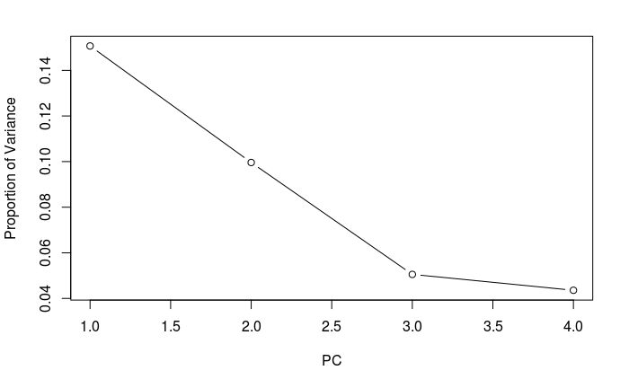

```r
plot(summary(pca.mod))
```

Visualize PCA analysis

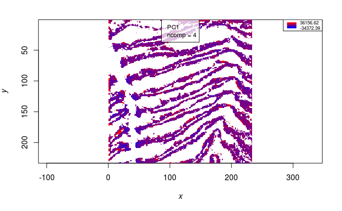

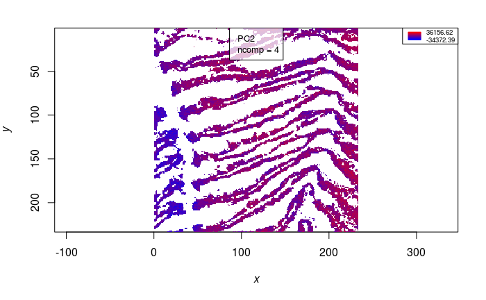

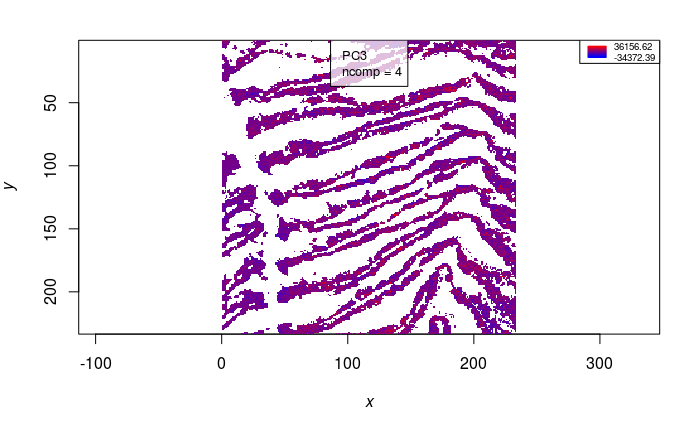

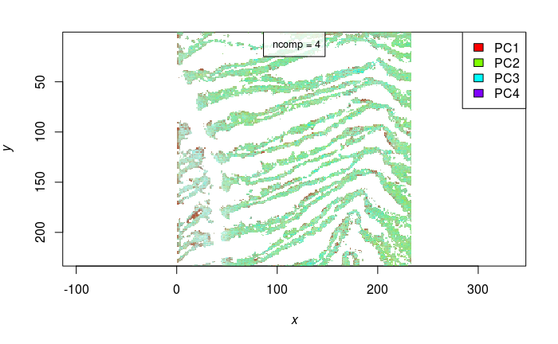

```r
mycols<-gradient.colors(10,start='Blue', end='Red')
image(pca.mod, column=c('PC1','PC2','PC3'), superpose=F, col.regions=mycols)

image(pca.mod, column=c('PC1','PC2','PC3'), superpose=T, col.regions=mycols)
```

We can see clear seperation in the data based on PC components 1 and 2. We can also plot these points as “normal” score plots below colored by FISH annotation

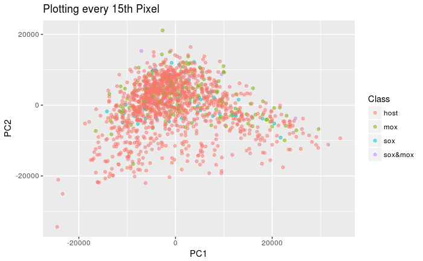

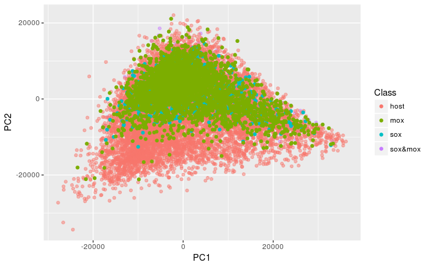

Clearly there is a large variation in the host tissue. Just to confirm, re-run PCA with just host pixels

```r
maldifishmz.host<-maldifishmz[,maldifishmz$Class=='Tissue']
pca.mod.2<-PCA(maldifishmz.host,ncomp=3)
```

```
PCA: Fitting principal components.
PCA: Done.
```

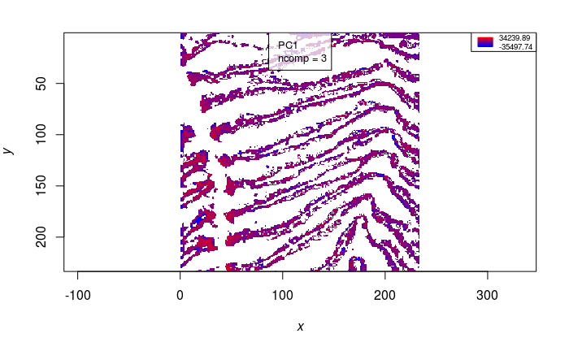

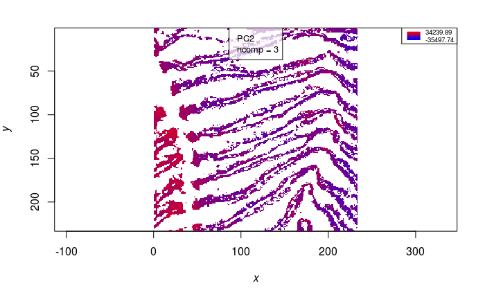

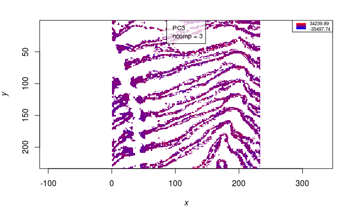

```r
image(pca.mod.2, column=c('PC1','PC2','PC3'), superpose=F, col.regions=mycols)
```

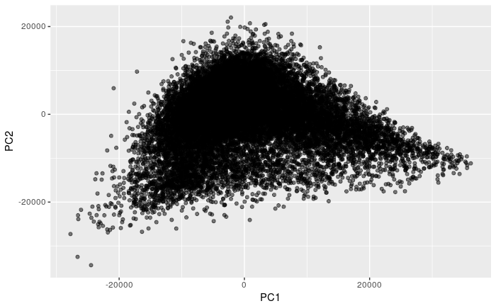

```r
pca.scores.red<-as.data.frame(pca.mod.2[[1]]$scores)
ggplot(pca.scores, aes(x=PC1, y=PC2)) + geom_point(alpha=0.5)
```

# CLUSTERING ANALYSIS

To confirm observation that ciliated edge host pixels cluster independently of the tissue pixels in the symbiont region, we can visualize the unsupervised clustering of the comlete dataset using spatially aware k-means clustering method.

Load in clustering data

```r
setwd(file.path(dir,'Results'))
```

[output not shown]

```r
setwd(file.path(dir,'Results'))
load('unsupervised-clustering-anlaysis.RData')
load('unsupervised-clustering-anlaysis.RData')
ls()
```

```
 [1] "df"                   "dir"                  "int_matrix"           "maldifishmz"          "maldifishmz.host"     "mycols"
 [7] "pca.mod"              "pca.mod.2"            "pca.scores"           "pca.scores.green"     "pca.scores.mixed"     "pca.scores.red"
[13] "pca.scores.reduced"   "pca.scores.symbionts" "pca.scores.tissue"    "peaks_in_data"        "pixelNo"              "randNum"
[19] "skma"                 "skmg"
```

### Unsupervized

```r
print('adaptive')
```

```
[1] "adaptive"
```

```r
summary(skma)
```

```
  r k   method   time Within-Cluster SS Between-Cluster SS     Total SS
1 1 3 gaussian 25.299      9.197815e+12       1.495462e+12 1.069328e+13
2 1 5 gaussian 28.075      8.756170e+12       1.937107e+12 1.069328e+13
3 1 7 gaussian 32.455      8.429798e+12       2.263479e+12 1.069328e+13
4 2 3 gaussian 24.984      9.337381e+12       1.355896e+12 1.069328e+13
5 2 5 gaussian 28.335      8.954518e+12       1.738759e+12 1.069328e+13
6 2 7 gaussian 32.396      8.679523e+12       2.013755e+12 1.069328e+13
```

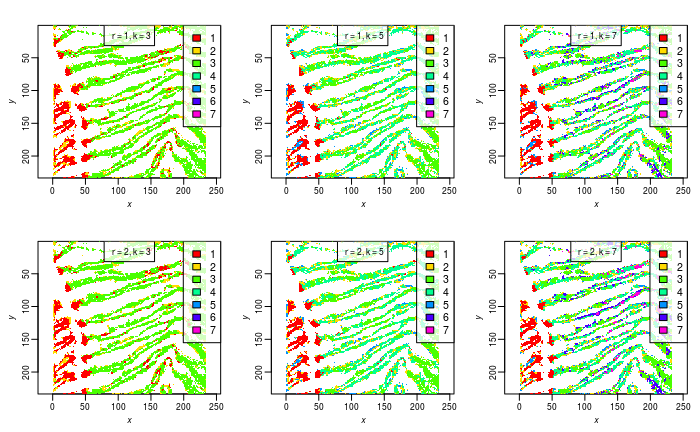

```r
image(skma, key = T, layout = c(3, 2))
```

```r
print('gaussian')
```

```
[1] "gaussian"
```

```r
summary(skmg)
```

```
  r k   method   time Within-Cluster SS Between-Cluster SS     Total SS
1 1 3 gaussian 25.850      9.197815e+12       1.495462e+12 1.069328e+13
2 1 5 gaussian 27.884      8.756427e+12       1.936850e+12 1.069328e+13
3 1 7 gaussian 31.448      8.429798e+12       2.263479e+12 1.069328e+13
4 2 3 gaussian 25.179      9.337381e+12       1.355896e+12 1.069328e+13
5 2 5 gaussian 29.174      8.954518e+12       1.738759e+12 1.069328e+13
6 2 7 gaussian 31.902      8.679523e+12       2.013755e+12 1.069328e+13
```

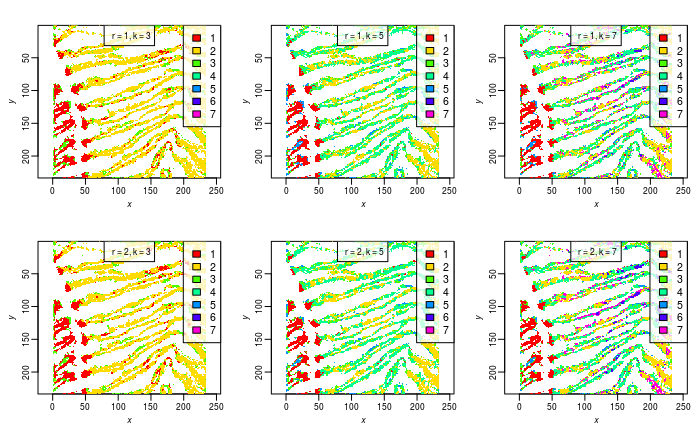

```r
image(skmg, key = T, layout = c(3,2))
```

In all cases, the ciliated edge clusters indepenentdely from the other tissue portions. Additionally, it looks like the adaptive and bausian methods preform about the same.

### Supervised

In this analysis a supervised method was used to cluster the dataset into groups (n=4) based on our classification calles through the FISH data.

Load in data

```r
setwd(file.path(dir,'Results'))
load('supervised-clustering-anlaysis.RData')
ls()
```

```
 [1] "ciliated"               "ciliatedEdge"           "ciliatedEdge.subset"    "ciliated.opls"          "ciliated.opls.cv"       "clust.groups"
 [7] "coordsSubset"           "ddd"                    "ddd.x"                  "ddd.y"                  "df"                     "dir"
[13] "dnew"                   "group1"                 "grp1"                   "hostvssym"              "int_matrix"             "maldifishmz"
[19] "maldifishmz.host"       "maldifishmz.newclass"   "mer"                    "msidata"                "msidata.nociliatededge" "mycols"
[25] "nociliatededge.subset"  "opls"                   "opls.cv"                "opls.scores"            "pca.mod"                "pca.mod.2"
[31] "pca.nociliated"         "pca.scores"             "pca.scores.green"       "pca.scores.mixed"       "pca.scores.red"         "pca.scores.reduced"
[37] "pca.scores.symbionts"   "pca.scores.tissue"      "peaks_in_data"          "pixelNo"                "randNum"                "sigIons"
[43] "skma"                   "skmg"                   "ssc"                    "ssca.cv"                "sscg.cv"                "subset"
[49] "symhost.opls"           "sym.host.opls.cv"       "t0"
```

Summarize the supervised clustering analysis for both gaussian and adaptive methods

Gaussian

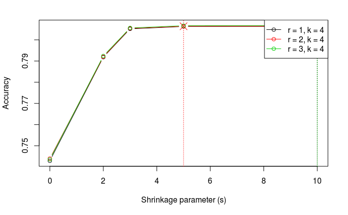

Adaptive

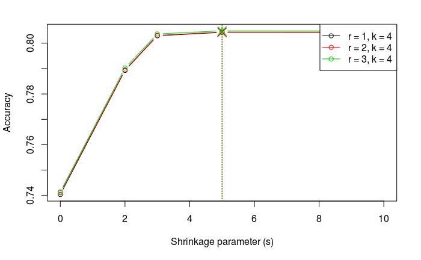

No difference bewteen the different radius adn the hitest accuracy value is at s=5, slightly more accuate for the adaptive method.

Plots the calls for the different cross validation groups for the adaptive method

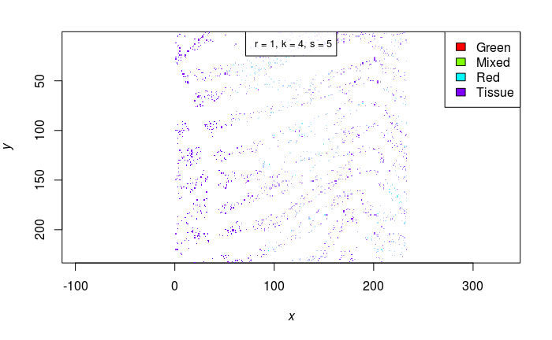

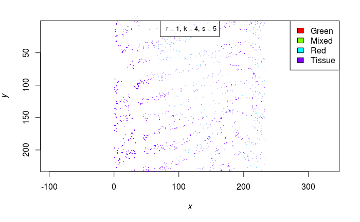

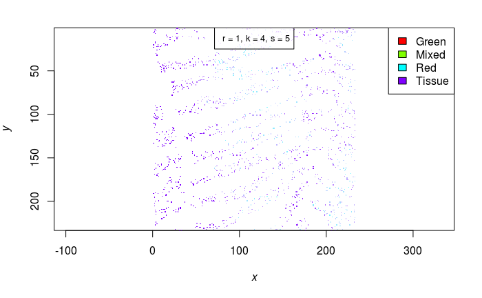

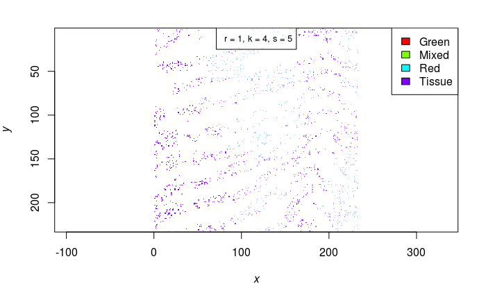

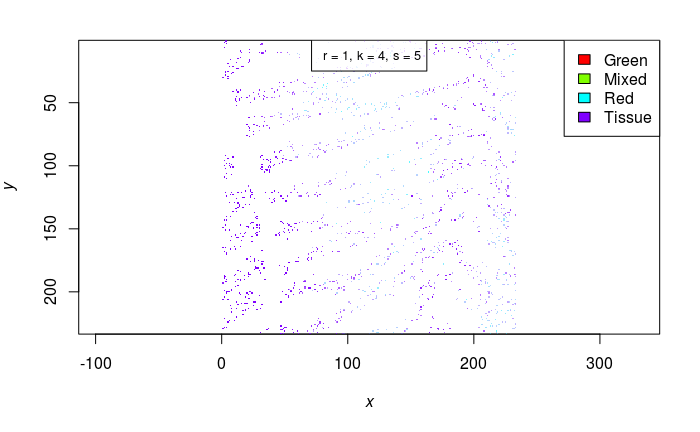

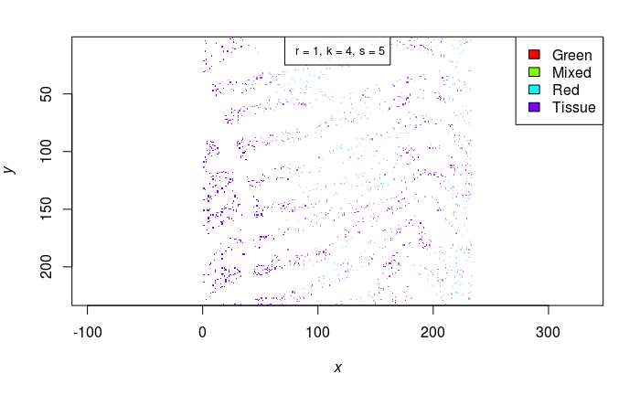

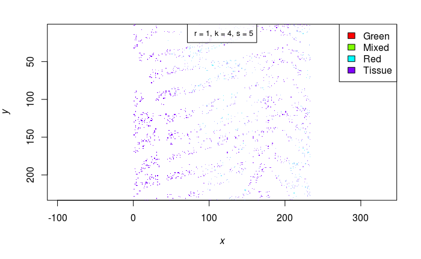

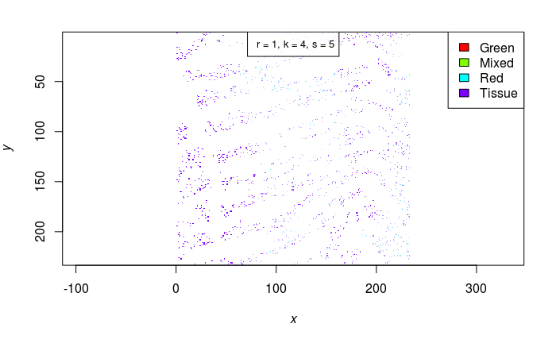

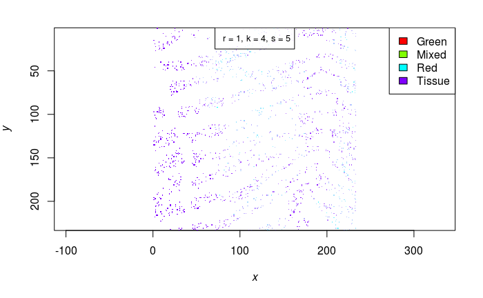

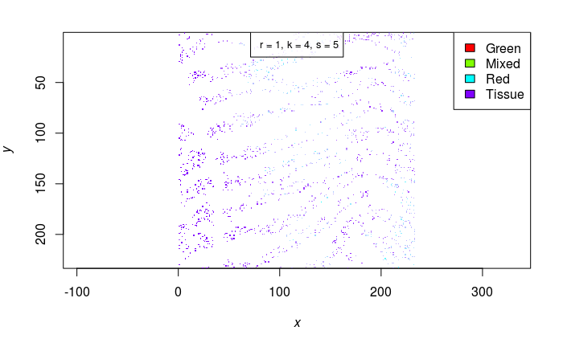

These are the t-stats for the differnet ions that lead to differences between groups

```r
ssc<-spatialShrunkenCentroids(maldifishmz,y=as.factor(maldifishmz$Class), r=3, s=5,method='adaptive')
```

```
spatialShrunkenCentroids: Calculating shrunken centroids for s = 5.
spatialShrunkenCentroids: Expanding results for r = 3.
spatialShrunkenCentroids: Predicting classes for r = 3, k = 4, s = 5.
spatialShrunkenCentroids: Done.
```

```r
ssc<-spatialShrunkenCentroids(maldifishmz,y=as.factor(maldifishmz$Class), r=3, s=5,method='adaptive')
```

```
spatialShrunkenCentroids: Calculating shrunken centroids for s = 5.
spatialShrunkenCentroids: Expanding results for r = 3.
spatialShrunkenCentroids: Predicting classes for r = 3, k = 4, s = 5.
spatialShrunkenCentroids: Done.
```

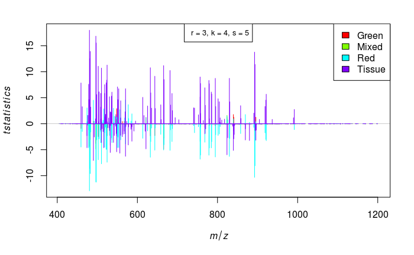

```r
plot(ssc, mode='tstatistics', model=list(r=3, s=5))
```

Summerize results here

```r
summary(ssc)
```

```
  r k s   method   time Predicted # of Classes Mean # of Features per Class
1 3 4 5 adaptive 60.224                      3                           90
```

```r
sigIons<-topLabels(ssc, n=90)
sigIons<-sigIons[order(sigIons$mz),]
sigIons
```

|  | mz | r | k | s | classes | centers | tstatistics | p.values | adj.p.values |
| --- | --- | --- | --- | --- | --- | --- | --- | --- | --- |
| 22 | 459.2494 | 3 | 4 | 5 | Tissue | 207.86158 | 7.844322 | 4.662937e-15 | 1.685893e-12 |
| 65 | 462.3349 | 3 | 4 | 5 | Tissue | 35.77109 | 3.281688 | 1.034211e-03 | 8.961740e-02 |
| 69 | 474.2589 | 3 | 4 | 5 | Red | 423.92051 | 3.037532 | 2.404410e-03 | 1.895506e-01 |
| 25 | 478.3303 | 3 | 4 | 5 | Tissue | 880.53828 | 7.584024 | 3.552714e-14 | 1.128794e-11 |
| 47 | 479.3339 | 3 | 4 | 5 | Tissue | 79.85195 | 4.632786 | 3.637808e-06 | 4.828154e-04 |
| 1 | 480.3454 | 3 | 4 | 5 | Tissue | 1481.00227 | 17.993608 | 0.000000e+00 | 0.000000e+00 |
| 6 | 481.3494 | 3 | 4 | 5 | Tissue | 196.80591 | 12.528334 | 0.000000e+00 | 0.000000e+00 |
| 80 | 482.3246 | 3 | 4 | 5 | Tissue | 31.32135 | 2.495625 | 1.258408e-02 | 8.512523e-01 |
| 4 | 482.3613 | 3 | 4 | 5 | Tissue | 316.02818 | 13.919077 | 0.000000e+00 | 0.000000e+00 |
| 66 | 483.3637 | 3 | 4 | 5 | Tissue | 25.66951 | 3.200104 | 1.376612e-03 | 1.157764e-01 |

[output cut: 80 more lines]

Looks like we can accurately predict the mox signals from the tissue signals, but definitely can’t classify out the mixed signals (we do get some significant ions for the sox) Maybe worth repeating by taking out the mixed signal and running more cvs and potentially adding in a category for the ciliated edge tissue sections

# DISCRIMINATE ANALYSIS

Next steps: Res-assign class groups by calling pixels from ciliated edge, cilated (in the clustering analysis this correpsonds to cluster group 1) & run OPLS-DA

```r
pca.nociliated<-PCA(msidata.nociliatededge,ncomp=3)
```

```
PCA: Fitting principal components.
PCA: Done.
```

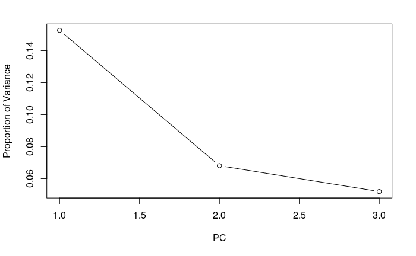

```r
plot(summary(pca.nociliated))
```

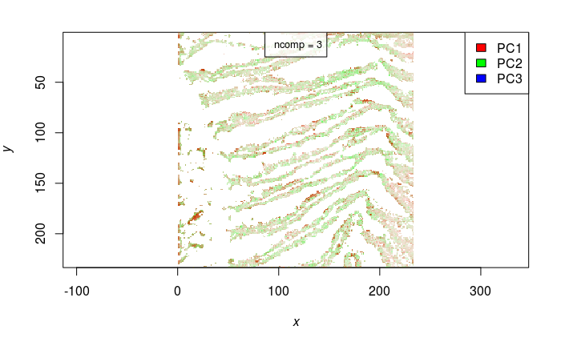

```r
image(pca.nociliated, column=c('PC1','PC2'), superpose=T)
```

Comparing ciliated edge vs. tissue

```r
ciliatedEdge<-msidata[,msidata$Class %in% c('CiliatedEdge', 'Tissue')]
table(ciliatedEdge$Class)
```

```
CiliatedEdge       Tissue
        2197        14914
```

```r
ddd<-data.frame(pData(ciliatedEdge))
ddd$xy<-paste(ddd$x, ddd$y,sep='-')
subset<-data.frame((pData(ciliatedEdge) %>% group_by(Class) %>% sample_n(size=1000,replace = F)))
subset$xy<-paste(subset$x, subset$y,sep='-')
dnew<-ddd[ddd$xy %in% subset$xy,]
coordsSubset<-rownames(dnew)
ciliatedEdge.subset<-ciliatedEdge[,rownames(pData(ciliatedEdge)) %in% coordsSubset]
ciliatedEdge.subset
```

```
An object of class "MSImageSet"
Slot "processingData":
Processing data
  Cardinal version: 1.7.0
  Files: /opt/extern/bremen/symbiosis/sogin/MALDIFISH/Data/20161206_MPIBremen_Bputeoserpentis_MALDI-FISH8_Sl16_s1_DHB_233x233_3um.imzML
         /opt/extern/bremen/symbiosis/sogin/MALDIFISH/Data/20161206_MPIBremen_Bputeoserpentis_MALDI-FISH8_Sl16_s1_DHB_233x233_3um.ibd
  Normalization: tic
  Smoothing:
  Baseline reduction:
  Spectrum representation:
  Peak picking: adaptive

Slot "experimentData":
Experiment data
  Experimenter name:
  Laboratory:
  Contact:
  Title:
  URL:
  PMIDs:
  No abstract available.

Slot "imageData":
An object of class 'MSImageData'
  iData: 3495 x 2000 matrix (53.3 Mb)
  mzData: 3495 x 2000 Hashmat (25.9 Mb)
  peakData: 3495 x 2000 Hashmat (25.9 Mb)

Slot "pixelData":
An object of class 'IAnnotatedDataFrame'
  pixelNames: x = 4, y = 1 x = 38, y = 1 ... x = 131, y = 233 (2000 total)
  varLabels: x y ... cvgroup (5 total)
  varMetadata: labelType labelDescription

Slot "featureData":
An object of class 'AnnotatedDataFrame'
  featureNames: m/z = 405.059 m/z = 408.009 ... m/z = 1199.171 (3495 total)
  varLabels: mz
  varMetadata: labelDescription

Slot "protocolData":
An object of class 'AnnotatedDataFrame': none

Slot ".__classVersion__":
         R    Biobase       iSet  SImageSet MSImageSet
   "3.2.4"   "2.30.0"    "0.1.0"    "0.1.0"    "0.7.0"
```

```r
table(ciliatedEdge.subset$Class)
```

```
CiliatedEdge       Tissue
        1000         1000
```

```r
pixelNo<-nrow(pData(ciliatedEdge.subset))
randNum<-sample(1:10,size = pixelNo,replace = T) ## For now, just split the data 10 ways, increase to see how changes in overnight run
pData(ciliatedEdge.subset)$cvgroup<-as.vector(randNum)
```

OPLS

```r
ciliated.opls.cv<-cvApply(ciliatedEdge.subset, .y = as.factor(ciliatedEdge.subset$Class), .fun = "OPLS", ncomp = 1:12, keep.Xnew = FALSE, .fold=cvgroup)
```

[output not shown]

[output cut: 235 more lines]

[output not shown]

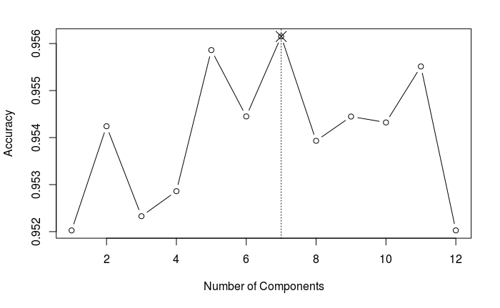

```r
plot(summary(ciliated.opls.cv))
```

Re-run opls with correct number of components as predicted from model above and visualize

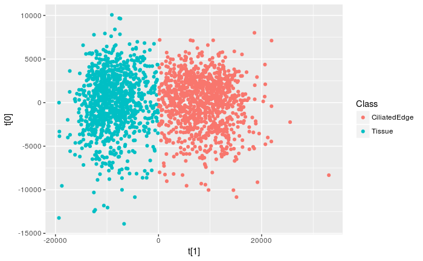

Conclusions: There are clear differences in the metabolome between the tissue pixels and the ciliated edge pixels. This is intriguing because it suggests that either the host is somehow controlling the symbiont assemablges at the cilaited edge of the tissue through secretion of interesting metabololites (check annotations) or the symbionts are some how re-modeling the tissue structures inside the host tissue. Could be a nice interesting comparison of how hosts are different with bacteria and without.

Either way, we will need to keep the ciliated edge pixels out of the complete analysis.

### OPLS Analysis with Ciliated Edge Category

```r
msidata<-msidata[,!msidata$Class %in% c('Mixed')]
table(msidata$Class)
```

```
CiliatedEdge        Green          Red       Tissue
        2197          788         3022        14914
```

```r
ddd<-data.frame(pData(msidata))
ddd$xy<-paste(ddd$x, ddd$y,sep='-')
subset<-data.frame((pData(msidata) %>% group_by(Class) %>% sample_n(size=700,replace = F)))
subset$xy<-paste(subset$x, subset$y,sep='-')
dnew<-ddd[ddd$xy %in% subset$xy,]
coordsSubset<-rownames(dnew)
msidata.subset<-msidata[,rownames(pData(msidata)) %in% coordsSubset]
msidata.subset
```

```
An object of class "MSImageSet"
Slot "processingData":
Processing data
  Cardinal version: 1.7.0
  Files: /opt/extern/bremen/symbiosis/sogin/MALDIFISH/Data/20161206_MPIBremen_Bputeoserpentis_MALDI-FISH8_Sl16_s1_DHB_233x233_3um.imzML
         /opt/extern/bremen/symbiosis/sogin/MALDIFISH/Data/20161206_MPIBremen_Bputeoserpentis_MALDI-FISH8_Sl16_s1_DHB_233x233_3um.ibd
  Normalization: tic
  Smoothing:
  Baseline reduction:
  Spectrum representation:
  Peak picking: adaptive

Slot "experimentData":
Experiment data
  Experimenter name:
  Laboratory:
  Contact:
  Title:
  URL:
  PMIDs:
  No abstract available.

Slot "imageData":
An object of class 'MSImageData'
  iData: 3495 x 2800 matrix (74.7 Mb)
  mzData: 3495 x 2800 Hashmat (34.4 Mb)
  peakData: 3495 x 2800 Hashmat (34.4 Mb)

Slot "pixelData":
An object of class 'IAnnotatedDataFrame'
  pixelNames: x = 29, y = 1 x = 31, y = 1 ... x = 214, y = 233 (2800 total)
  varLabels: x y ... cvgroup (5 total)
  varMetadata: labelType labelDescription

Slot "featureData":
An object of class 'AnnotatedDataFrame'
  featureNames: m/z = 405.059 m/z = 408.009 ... m/z = 1199.171 (3495 total)
  varLabels: mz
  varMetadata: labelDescription

Slot "protocolData":
An object of class 'AnnotatedDataFrame': none

Slot ".__classVersion__":
         R    Biobase       iSet  SImageSet MSImageSet
   "3.2.4"   "2.30.0"    "0.1.0"    "0.1.0"    "0.7.0"
```

```r
table(msidata.subset$Class)
```

```
CiliatedEdge        Green          Red       Tissue
         700          700          700          700
```

```r
pixelNo<-nrow(pData(msidata.subset))
randNum<-sample(1:10,size = pixelNo,replace = T) ## For now, just split the data 10 ways, increase to see how changes in overnight run
pData(msidata.subset)$cvgroup<-as.vector(randNum)
```

OPLS cv analysis

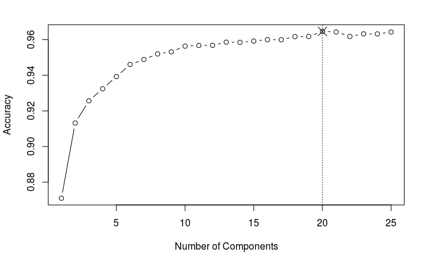

Visualization

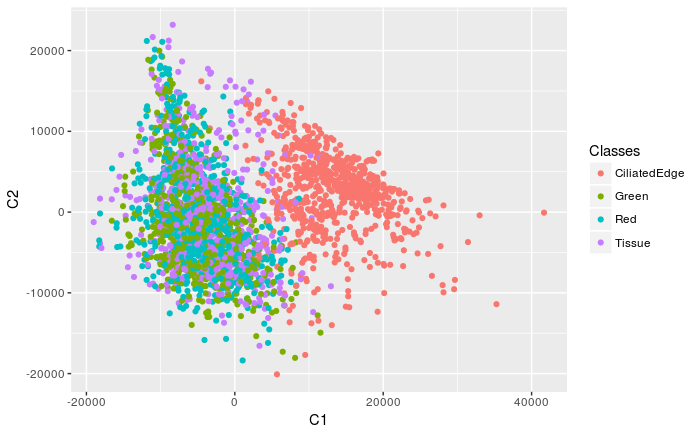